```python
import numpy as np
from imageio import imread
import matplotlib.pyplot as plt
from scipy.signal import convolve2d

car = imread("../images/car.png", as_gray=True)
F = np.fft.fft(car[100])
M = len(F)
N = len(car)
sinus = lambda i, u: np.sin(2*np.pi*u*i/M)
cosinus = lambda i, u: np.cos(2*np.pi*u*i/M)
```

<- Tilbake til liste over notater

# Litt om forrige forelesning

### Det som skal skje:

- Litt om sinus
- 1D Eksempel på Fourier transform
- 2D Forklaring på Fourier transform

## Sinus og cosinus

$$ \sin{(x)}, x \in [0, 2\pi) $$

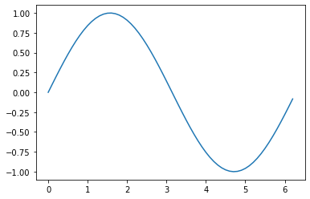

```python
index = np.arange(0,2*np.pi,0.1)
plt.plot(index, [np.sin(i) for i in index])
```

I Fourier transform får vi denne funksjonen til å mappe fra 0 til M slik vi trenger. Dvs, alle våre x-er skal skaleres til mellom 0 og 2$\pi$. Dette gjør vi slik: $$ \frac{x}{M} 2 \pi, \frac{x}{M} \in [0,1) $$ Feks, for x=0 og M = 256: $$ \frac{0}{256} 2 \pi = 0$$ for x=128: $$ \frac{128}{256} 2 \pi = \pi$$

Når vi øker frekvensen, mapper vi til et større intervall, feks 4$\pi$, 6$\pi$, osv.

Feks, for x=128 som mappes til 6$\pi$: $$ \frac{128}{256} 6 \pi = 3\pi$$

Dette betegnes med $ \frac{x}{M} u 2 \pi $ og slik får vi den sinusen vi bruker: $$ \sin{\big(\frac{x}{M} u 2 \pi\big)} $$

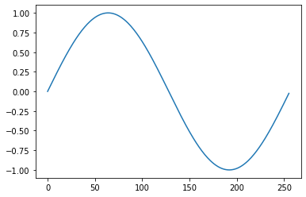

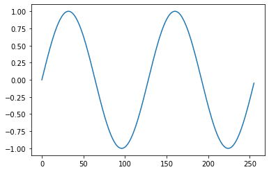

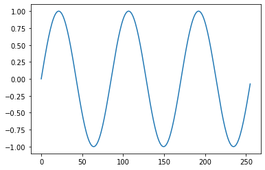

```python
plt.figure()
plt.plot([sinus(i,1) for i in range(M)])
plt.figure()
plt.plot([sinus(i,2) for i in range(M)])
plt.figure()
plt.plot([sinus(i,3) for i in range(M)])
```

Så, en til dimensjon, der y mapper likedan:

$$ \sin{\bigg(\frac{x}{M} u 2 \pi + \frac{y}{N} v 2 \pi\bigg)} $$

Som gir slike bilder:

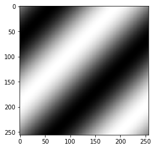

```python
sinus2D = lambda x,y,u,v: np.sin((-x*u*2*np.pi/M-y*v*2*np.pi/N))
plt.imshow([[sinus2D(i,j,1,1) for j in range(M)] for i in range(N)], cmap="gray")
```

Vi bruker den samme sinus funksjonen, det er ingenting spesielt med at vi putter inn flere tall. Vi mapper en x og en y til en normal sinus fortsatt. Hvis vi putter inn en viss x, gir det mening at en y vil få oss lengre frem i sinusen.

## Fourier transform

Alle funksjoner kan tilnærmes med uendelig mange sinus og cosinus funksjoner. Vi jobber med diskré funksjoner, og dette er ikke noe problem for Fourier.

Et 1D eksempel: $$F(u) = \sum_{x=0}^{M-1} f(x) e^{-2 \pi j \frac{u x}{M}} $$ Vi vil tilnærme en linje fra bildet car.png:

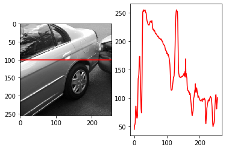

```python
fig = plt.figure()
fig.add_subplot(1,2,1)
plt.plot([100 for i in range(len(car))], color="red")
plt.imshow(car, cmap="gray")
fig.add_subplot(1,2,2)
plt.plot(car[100], color="red")
```

Vi vil tilnærme denne funksjonen med sinus og cosinus.

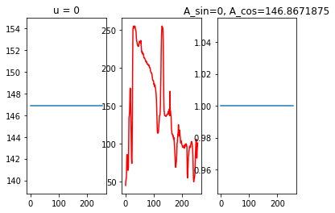

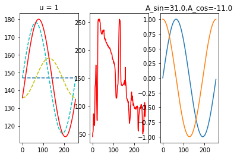

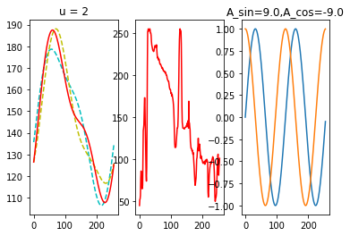

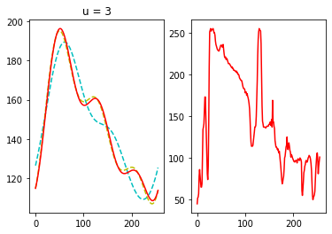

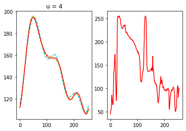

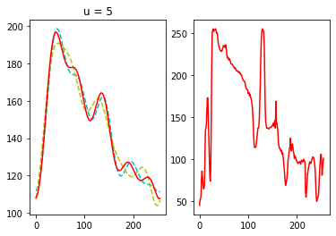

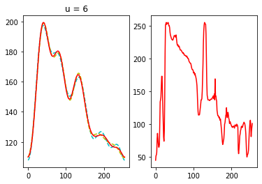

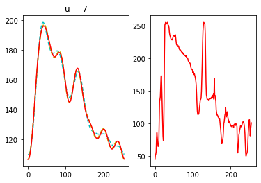

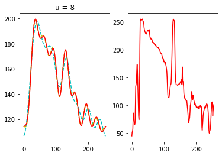

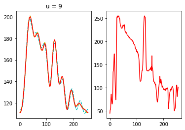

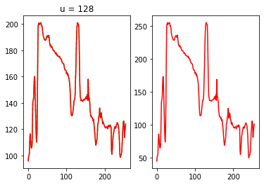

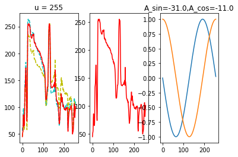

```python
middelverdi = np.real(F[0])/M
basis0 = np.array([middelverdi for i in range(M)])


fig = plt.figure()
fig.add_subplot(1,3,1)
plt.plot(basis0)
plt.title("u = 0")
fig.add_subplot(1,3,2)
plt.plot(car[100], color="red")
fig.add_subplot(1,3,3)
plt.plot(basis0/middelverdi)
plt.title("A_sin=0, A_cos="+str(middelverdi))



middelverdi = np.real(F[0])/M
basis0 = np.array([middelverdi for i in range(M)])
lookAlike = basis0.copy()

for u in range(1,M):
    unscaledSin = np.array([sinus(i,u) for i in range(M)])
    unscaledCos = np.array([cosinus(i,u) for i in range(M)])
    basisUsin = -np.imag(F[u])/M * unscaledSin
    basisUcos = np.real(F[u])/M * unscaledCos

    if u < 10 or u == M-1 or u == M//2:
        fig = plt.figure()
        fig.add_subplot(1,3 if u < 3 or u == 255 else 2,1)
        if u < 2:
            plt.plot(lookAlike, "--")
        plt.plot(lookAlike + basisUsin, "c--")
        plt.plot(lookAlike + basisUcos, "y--")
        plt.title("u = "+str(u))

    lookAlike += (basisUsin + basisUcos)
    if u < 10 or u == M-1 or u == M//2:
        plt.plot(lookAlike, color="red")

        fig.add_subplot(1,3 if u < 3 or u == 255 else 2,2)
        plt.plot(car[100], color="red")

        if u < 3 or u == 255:
            fig.add_subplot(1,3,3)
            plt.plot(unscaledSin)
            plt.plot(unscaledCos)
            plt.title("A_sin="+str(np.round(-np.imag(F[u])/M))+",A_cos="+str(np.round(np.real(F[u])/M)))
```

### Noen ting å merke seg:

- Ingen informasjon går tapt i dikré Fourier transformasjon: Før og etter er identisk
- Amplitude for cosinus er lik for u = 1 som u = 255
- Amplitude for sinus er akkurat motsatt
- u = 128 ser formlikt ut som u = 255, men skalert forskjellig

Den største mulige frekvensen er på cirka u,v=N/2. Denne avkuttingen gjør livet enkelt for oss når en kontinuerlig Fourier transformasjon ville fortsatt uendelig lenge.

Dette minner om Nyquist: $f_{sample} > 2 f_{max}$. Vi trenger å sample en topp og en dal og helst litt mer, så i et bilde med NxN piksler, kan vi ikke ha frekvenser med større hyppighet enn dette. Ettersom vi mapper x og y til et større og større sinus intervall, går vi forbi punktet vi kan sample med de skrittene vi tar på $\frac{x}{M}$, og gjennom en aliasing effekt går co-/sinusbildene våre tilbake til lave frekvenser.

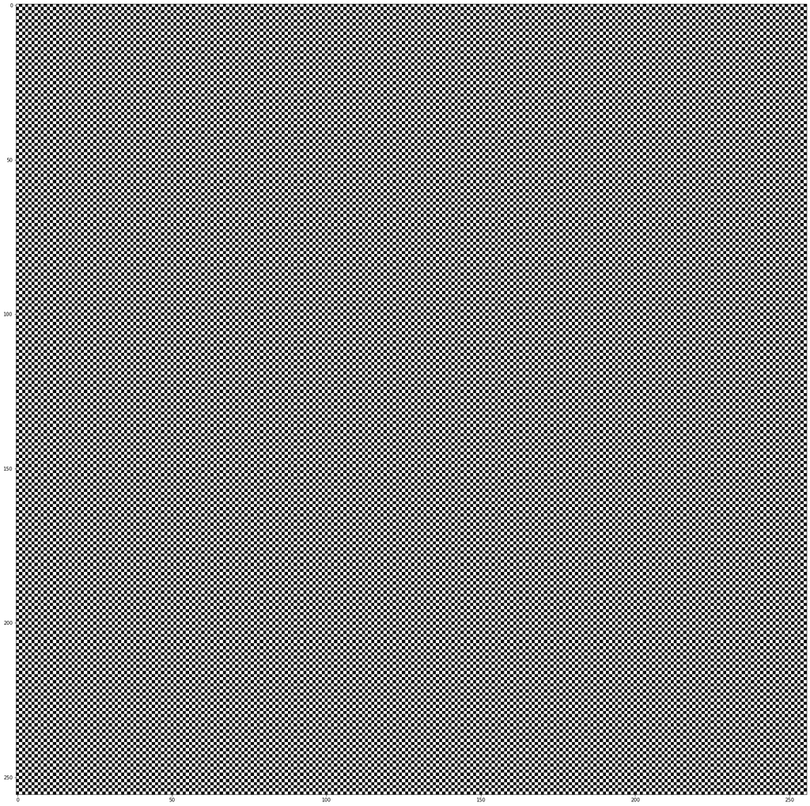

```python
cosinus2D = lambda x,y,u,v: np.cos((((x*u*2*np.pi)/(M))+((y*v*2*np.pi)/(N))))
plt.figure()
f, ax = plt.subplots(1, 1, figsize = (30, 30))
plt.imshow([[cosinus2D(i,j,M//2,N//2) for i in range(M)] for j in range(N)], cmap="gray")
```

## Men hvordan fant jeg amplitudene?

På forelesningen snakket Kristine om indreprodukt. Jeg vil her visualisere det litt mer.

Dette er formelen for DFT fra foilene:

$$ F(u,v) = \sum_{x=0}^{M-1} \sum_{y=0}^{N-1} f(x,y) * e^{-2 \pi j ( \frac{ux}{M} + \frac{vy}{N} )} $$

Det kan være nyttig og tenke på den slik:

$ F(u,v) = sum (bilde * cosinus\_bilde(u,v) , sum (bilde * sinus\_bilde(u,v) $

$ F(u,v) = sum \Big($

[figure not shown]

$\Big), sum \Big($

[figure not shown]

$\Big)$

Under finner jeg F(u,v) for de 20x20 første frekvensene:

(All koden her er for å illustrere, men spesielt her bør den ikke kjøres med n,m > 20)

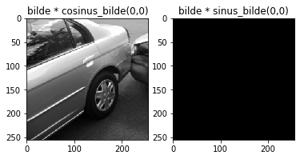

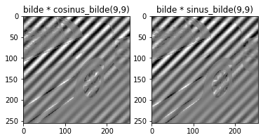

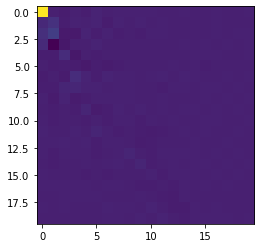

```python
cosinus_bilde = lambda u, v: [[cosinus2D(i,j,u,v) for i in range(M)] for j in range(N)]
sinus_bilde = lambda u, v: [[sinus2D(i,j,u,v) for i in range(M)] for j in range(N)]

n = m = 20
F_bad = np.zeros((n,m,2))

for u in range(m):
    for v in range(n):
        cosContribution = car * cosinus_bilde(u,v)
        sinContribution = car * sinus_bilde(u,v)
        if (u == 0 and v == 0) or (u == 9 and v == 9):
            fig = plt.figure()
            fig.add_subplot(1,2,1)
            plt.imshow(cosContribution, cmap="gray")
            plt.title("bilde * cosinus_bilde("+str(u)+","+str(v)+")")
            fig.add_subplot(1,2,2)
            plt.imshow(sinContribution, cmap="gray")
            plt.title("bilde * sinus_bilde("+str(u)+","+str(v)+")")
        F_bad[v,u,0] = np.sum(cosContribution)
        F_bad[v,u,1] = np.sum(sinContribution)

plt.figure()
showReal = [[F_bad[i][j][0] for j in range(n)] for i in range(n)]
plt.imshow(showReal)
```

Ser at (0,0) er veldig lys. Her er alle pikslene summert, fordi, som kan sees, bilde * cosinus_bilde(0,0) er bare bildet selv. Dette er fordi cosinus(0) = 1.

Når vi setter dette sammen igjen bruker vi formelen for iDFT, invers Fourier:

$$ f(x,y) = \frac{1}{M N} \sum_{u=0}^{M-1} \sum_{v=0}^{N-1} F(u,v) e^{2 \pi j ( \frac{ux}{M} + \frac{vy}{N} )} $$

som igjen kan tenkes på som

$ f = \sum_{u=0}^{M} \sum_{v=0}^{N} amplitude\_cos(u,v) * cos\_bilde(u,v) + amplitude\_sin(u,v) * sin\_bilde(u,v) $

$ f = \sum_{u=0}^{M} \sum_{v=0}^{N} A_{cos} *$

[figure not shown]

+ $ A_{sin}$$* $

[figure not shown]

der amplituden finnes ved å ta F(u,v), realdelen for cos, imaginærdelen for sin, og dele på antall piksler i bildet. Dette er en slags middelverdi av contribution.

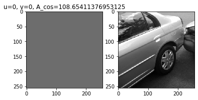

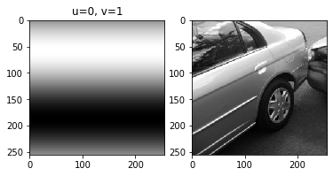

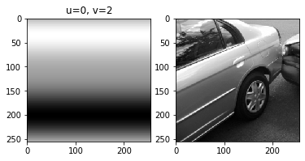

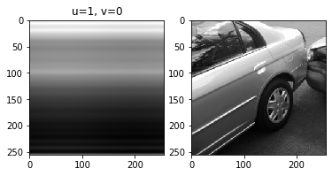

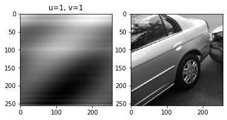

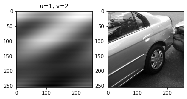

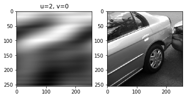

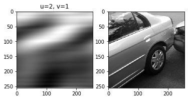

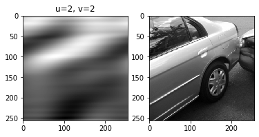

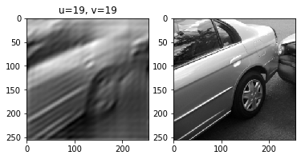

```python
car_bad = np.zeros((N,M))

for u in range(m):
    for v in range(n):
        a_cos = F_bad[v,u,0] / (N*M)
        a_sin = F_bad[v,u,1] / (N*M)
        car_bad += (a_cos * np.array(cosinus_bilde(u,v)))
        car_bad += (a_sin * np.array(sinus_bilde(u,v)))

        if (u < 3 and v < 3) or (u == m-1 and v == n-1):
            fig = plt.figure()
            fig.add_subplot(1,2,1)
            if u == 0 and v == 0:
                plt.title("u="+str(u)+", v="+str(v)+", A_cos="+str(a_cos))
                plt.imshow(car_bad, cmap="gray", vmin=0, vmax=255)
            else:
                plt.imshow(car_bad, cmap="gray")
                plt.title("u="+str(u)+", v="+str(v))
            fig.add_subplot(1,2,2)
            plt.imshow(car, cmap="gray")
```

## Og det var det :)